# UN Votes Group Project

Group 10: Chew Shi Zhan A0216042W, Lily Rozana Joehann Aung A0239463X, Joey Yang Yixuan A0239152H, Ng Ruo Yin A0240207W, Zhang Yue Rong Lucretia A0204359E

2023-08-30

# Introduction

The UN Votes TidyTuesday data contains three main datasets. The datasets are “unvotes”, “roll_calls” and “issues”. For “unvotes”, it contains the voting result of a wide variety of countries (yes, no or abstain) classified according to their roll call id (rcid). For “roll_calls”, it is a much wider dataset with more variables and information such as session number, “importantvote”, indicating whether the vote was classified as important by the U.S. State Department which began only after the 39th session, as well as “short” and “long” that provide descriptions with the extent of their depth based on their title. They also have other essential details such as the date, resolution code, whether the vote was on an amendment and only on a paragraph and not a resolution. Lastly, the “issues” dataset succinctly describes the specific conflict happening, if there was, according to the specific roll call id which comes with an issue code. These three datasets can be easily joined together for a clearer overview with the column “rcid” that they have in common.

# Descriptive Statistics

```r
# Tidying the data for Qn1
## Filtering out the data
unvotes_rdy <- unvotes %>%
  select(-c(country_code)) %>%
  left_join(roll_calls[, c("rcid", "date", "amend", "para")], by="rcid") %>%
  filter(format(date, format = "%Y") <= 1984,format(date, format = "%Y") >= 1956 ) %>%
  filter(para == 0) %>%
  mutate(vote = case_when(vote == "yes" ~ 1,
                          vote == "no" ~ -1,
                          vote == "abstain" ~ 0.5)) %>%
  select(rcid, country, vote) %>%
  pivot_wider(names_from=rcid, values_from=vote) %>%
  replace(is.na(.), 0)

## Plotting the cosine similarity matrix
voting_matrix <- unvotes_rdy[-1]
similarity_matrix <- cosine(t(as.matrix(voting_matrix)))
rownames(similarity_matrix) <- unvotes_rdy$country
colnames(similarity_matrix) <- unvotes_rdy$country
similarity_df <- as.data.frame(similarity_matrix)

# Descriptive Statistics for Qn1
a <- similarity_df %>%
  mutate_all(median)
b <- similarity_df %>%
  mutate_all(min)
c <- rbind(a[1,], b[1,])
rownames(c) <- c("Median of Similarity", "Min of Similarity")
c
```

|  | United States | Canada | Cuba | Haiti | Dominican Republic | Mexico | Guatemala | Honduras | El Salvador | Nicaragua | Costa Rica | Panama | Colombia | Venezuela | Ecuador | Peru | Brazil | Bolivia | Paraguay | Chile | Argentina | Uruguay | United Kingdom | Ireland | Netherlands | Belgium | Luxembourg | France | Spain | … |
| --- | --- | --- | --- | --- | --- | --- | --- | --- | --- | --- | --- | --- | --- | --- | --- | --- | --- | --- | --- | --- | --- | --- | --- | --- | --- | --- | --- | --- | --- | --- |
| Median of Similarity | 0.06312303 | 0.50510518 | 0.6809475 | 0.67727824 | 0.73396876 | 0.81601039 | 0.66463121 | 0.7050628 | 0.72986269 | 0.67689055 | 0.72023616 | 0.7853080 | 0.7799732 | 0.8074592 | 0.80547196 | 0.80354598 | 0.7629783 | 0.74059880 | 0.61409023 | 0.74062171 | 0.78160091 | 0.73507055 | 0.32443655 | 0.67889788 | 0.53149525 | 0.47226036 | 0.47216438 | 0.41856882 | 0.71671793 | … |
| Min of Similarity | -0.24520754 | 0.02600255 | -0.1182627 | 0.01327681 | 0.02534897 | 0.02360632 | 0.02631807 | 0.0255655 | 0.02541438 | 0.02517566 | 0.02463884 | 0.0120666 | 0.0121366 | 0.0237641 | 0.02422508 | 0.01191574 | 0.0240859 | 0.02504897 | 0.02769244 | 0.02437394 | 0.02411214 | 0.02449429 | -0.04968581 | 0.02550514 | 0.02496676 | 0.02554039 | 0.02554039 | 0.01387818 | 0.01267449 | … |

We first tidied the data by filtering out the years after and inclusive of 1985 as these years do not have values under the `para` column, and before and inclusive of 1955 to ensure both voting blocs have been established by then. The `para` column is essential as it allows us to only count votes that are on full resolutions. As highlighted in a report to the US Congress, including preliminary votes in calculating voting coincidence tends to distort the metric as these votes may not correspond to the country’s final stance on the resolution. We thus keep only the rows where `para` equals 0. We then assign “yes”, “no”, “abstain” votes with values 1, -1, and 0.5 respectively. NA values were created when pivoting the data wider, as some countries were not UN member states when some resolutions were voted on. These were replaced with the value 0. After cleaning the data, we calculated the cosine similarity between the voting patterns of countries and calculated the median and minimum value of pairwise similarity of each country against the other countries. Maximum value is not informative as it is always 1 since the country would be compared against itself. For instance then, the United States’ median similarity to other countries is about 0, suggesting it is generally not similar to other countries.

```r
# Tidying the data for Qn2
## Filtering the important votes
combined <- unvotes %>%
  left_join(issues,by='rcid') %>%
  left_join(roll_calls,by='rcid') %>%
  select(rcid,country,vote,issue,short,session,importantvote,date) %>%
  filter(importantvote==1& !is.na(issue))

## Calculate number of votes and the similarity index of each issue
important <- combined %>%
  group_by(rcid,issue,date,vote) %>%
  summarise(pro = n()) %>%
  spread(key=vote,value=pro) %>%
  mutate(similarity_index = (abs(yes-no)/(yes+no))*100) %>%
  drop_na(issue) %>%
  arrange(similarity_index)

# Descriptive Statistics for Qn2
## Distribution of Similarity Index
lapply(split(important$similarity_index,important$issue), summary)
```

```
## $`Arms control and disarmament`
##    Min. 1st Qu.  Median    Mean 3rd Qu.    Max.    NA's
##   10.00   71.44   95.00   80.74   98.70   98.87      13
##
## $Colonialism
##    Min. 1st Qu.  Median    Mean 3rd Qu.    Max.    NA's
##   60.00   80.85   84.47   85.22   94.59   97.69       2
##
## $`Economic development`
##    Min. 1st Qu.  Median    Mean 3rd Qu.    Max.    NA's
##   44.83   91.30   96.52   90.24   97.89   98.87       5
##
## $`Human rights`
##    Min. 1st Qu.  Median    Mean 3rd Qu.    Max.    NA's
##   8.219  49.541  81.241  69.659  87.096  98.889       3
##
## $`Nuclear weapons and nuclear material`
##    Min. 1st Qu.  Median    Mean 3rd Qu.    Max.    NA's
##   10.00   79.03   96.18   82.53   98.75   98.91       2
##
## $`Palestinian conflict`
##    Min. 1st Qu.  Median    Mean 3rd Qu.    Max.    NA's
##   10.00   82.24   86.09   84.04   90.33   98.63       4
```

# Question 1: Voting Patterns Amongst Countries

## Introduction

Our first research question would be “What countries seem to be voting in a synchronised/similar or opposing pattern and are there indicators of alliance via voting blocs or hostility?”. We were keen to investigate if there was any correlation between the voting pattern of countries within certain blocs associated with the UN. Analysing the data would potentially help us to understand geopolitical dynamics between countries. Interpreting the pattern of votes between individual countries as well as between blocs of countries reveals similarity in the foreign policy beliefs that underlie voting decisions.

## Methodology

Using the similarity matrix, we created two plots. First, a heatmap to answer question 1 on a more granular level. The heatmap plots the historical voting similarity between members of within NATO, within the Warsaw Pact and between select members across the two alliances. The heatmap is highly appropriate for visualising this information as the information is pairwise and there are a limited number of countries to plot for each group. The correspondence of colour intensity to the similarity scale also allows the viewer to quickly glean which countries are voting similarly. We focus on NATO and the Warsaw Pact as the major voting blocs as the period our dataset covers overlaps with the Cold War.

## Visualisation

### Plot 1

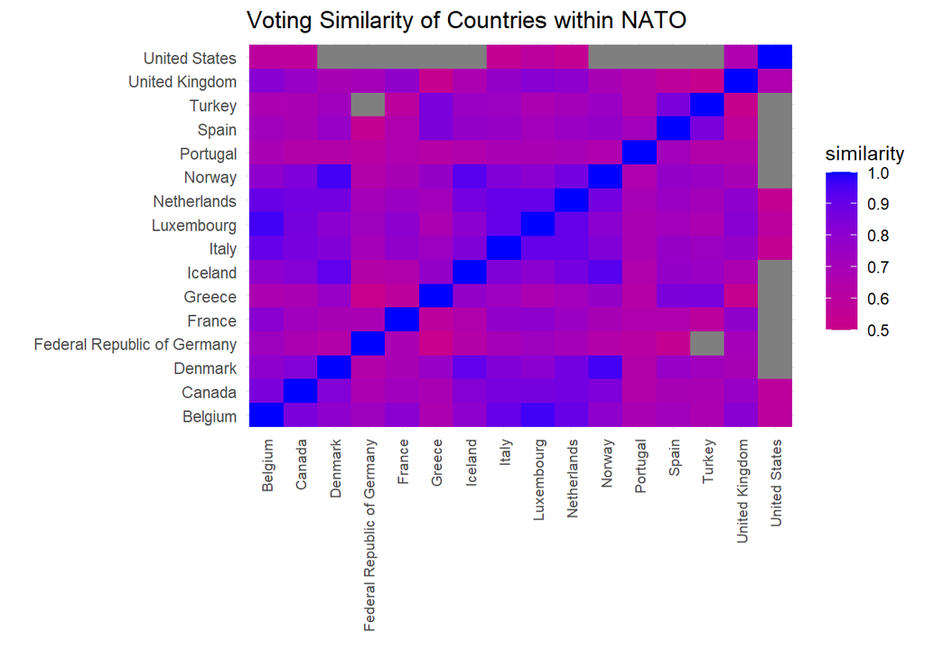

```r
NATO <- c("Belgium", "Canada", "Denmark", "France", "Iceland", "Italy", "Luxembourg", "Netherlands", "Norway", "Portugal", "United Kingdom", "United States", "Federal Republic of Germany", "Greece", "Turkey", "Spain")

NATO_tidy_matrix <- similarity_matrix[NATO, NATO] %>%
  as_tibble(rownames = "country1") %>%
  pivot_longer(-country1, names_to = "country2", values_to = "similarity")

ggplot(NATO_tidy_matrix, aes(x = country1, y = country2, fill = similarity)) +
  geom_tile() +
  scale_fill_gradient2(low = "white", mid = "red", high = "blue", limits = c(0.5, 1.0)) +
  labs(title = "Voting Similarity of Countries within NATO", x = "", y = "") +
  theme_minimal() +
  theme(axis.text.x  = element_text(angle=90, vjust=0.5, size=8, hjust=1))
```

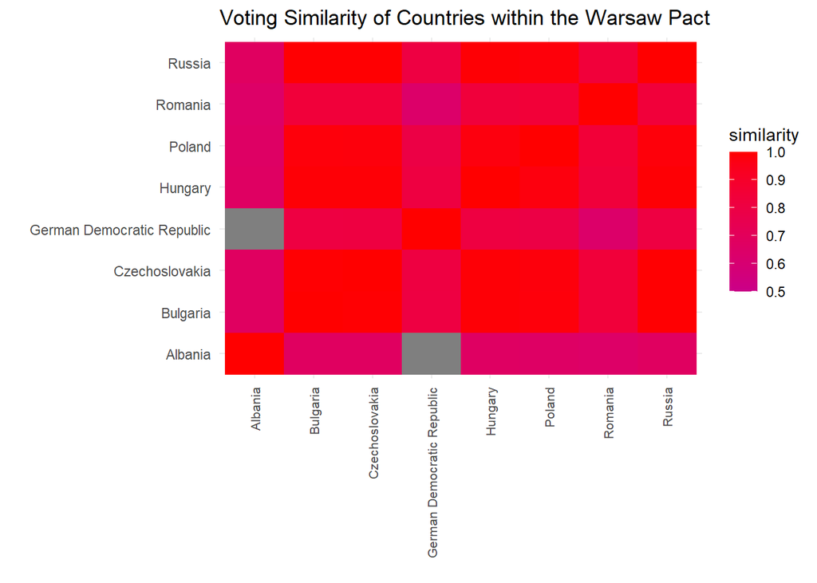

```r
Warsaw_Pact <- c("Albania", "Bulgaria", "Czechoslovakia", "German Democratic Republic", "Hungary", "Poland", "Romania", "Russia")

WP_tidy_matrix <- similarity_matrix[Warsaw_Pact, Warsaw_Pact] %>%
  as_tibble(rownames = "country1") %>%
  pivot_longer(-country1, names_to = "country2", values_to = "similarity")

ggplot(WP_tidy_matrix, aes(x = country1, y = country2, fill = similarity)) +
  geom_tile() +
  scale_fill_gradient2(low = "white", mid = "blue", high = "red", limits = c(0.5, 1.0)) +
  labs(title = "Voting Similarity of Countries within the Warsaw Pact", x = "", y = "") +
  theme_minimal() +
  theme(axis.text.x  = element_text(angle=90, vjust=0.5, size=8,hjust=1))
```

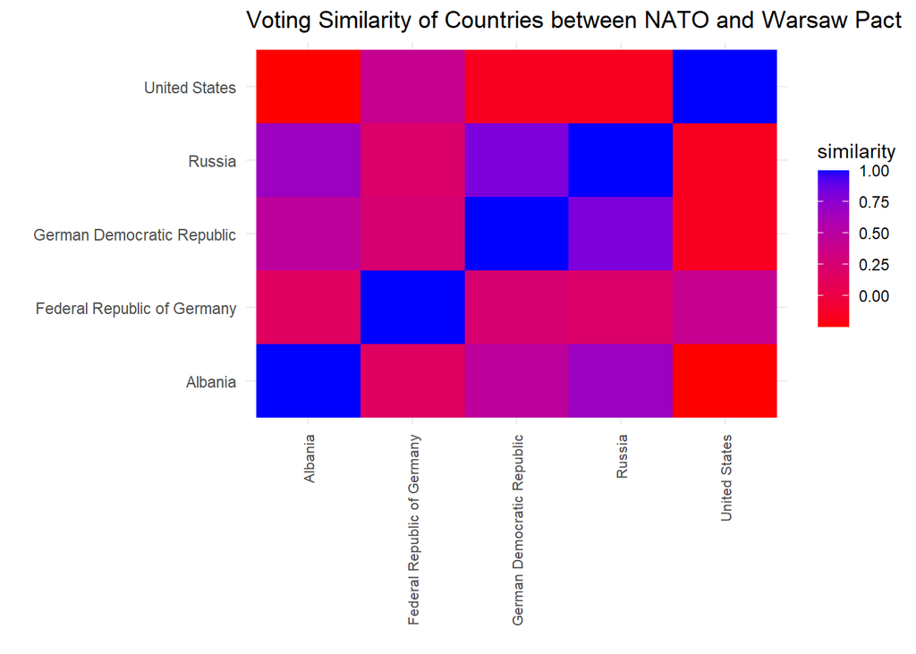

```r
Countries_between_NATO_WP <- c("United States", "Russia", "Albania", "German Democratic Republic", "Federal Republic of Germany")

Countries_between_NATO_WP_tidy_matrix <- similarity_matrix[Countries_between_NATO_WP, Countries_between_NATO_WP] %>%
  as_tibble(rownames = "country1") %>%
  pivot_longer(-country1, names_to = "country2", values_to = "similarity")

ggplot(Countries_between_NATO_WP_tidy_matrix, aes(x = country1, y = country2, fill = similarity)) +
  geom_tile() +
  scale_fill_gradient(low = "red", high = "blue") +
  labs(title = "Voting Similarity of Countries between NATO and Warsaw Pact", x = "", y = "") +
  theme_minimal() +
  theme(axis.text.x  = element_text(angle=90, vjust=0.5, size=8,hjust=1))
```

### Plot 2

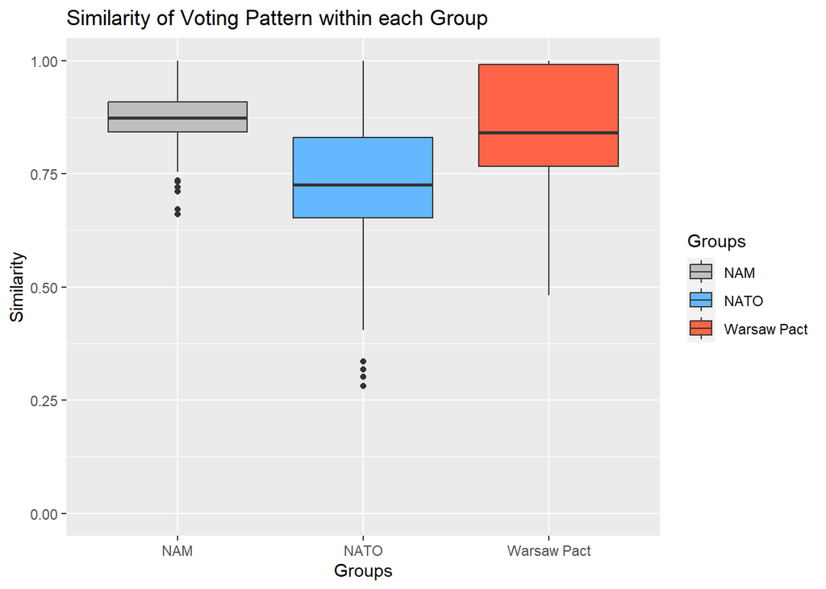

```r
NATO_data_frame <- as.data.frame(NATO_tidy_matrix)
WP_data_frame <- as.data.frame(WP_tidy_matrix)

nam_members <- c("Afghanistan", "Algeria", "Bangladesh", "Cuba", "Egypt", "India", "Indonesia", "Iraq", "Libya", "Mali", "Mexico", "Nigeria", "Sri Lanka", "Sudan", "Syria", "Tanzania", "Yugoslavia", "Zambia")
nam_tidy_matrix <- similarity_matrix[nam_members, nam_members] %>%
  as_tibble(rownames = "country1") %>%
  pivot_longer(-country1, names_to = "country2", values_to = "similarity")
nam_data_frame <- as.data.frame(nam_tidy_matrix)

WP_data_frame_group <- WP_data_frame %>%
  mutate(Groups = "Warsaw Pact")
nam_group <- nam_data_frame %>%
  mutate(Groups = "NAM")

df_combined <- NATO_data_frame %>%
  mutate(Groups = "NATO") %>%
  rbind(WP_data_frame_group,nam_group) %>%
  group_by(Groups)

ggplot(df_combined, aes(x=Groups, y=similarity, fill=Groups)) +
  geom_boxplot() +
  ylim(0,1) +
  scale_fill_manual(values=c("gray", "steelblue1", "tomato1")) +
  labs(title="Similarity of Voting Pattern within each Group",x="Groups",y="Similarity")
```

## Discussions

For the first two plots, greyed out squares indicate that the similarity of two countries are below 0.5 and considered insignificant. Blue represents high similarity with NATO states while red is high similarity within Warsaw Pact states. For NATO, the visual appearance of the plot is mostly blue, indicating that member states tend to vote in a synchronised manner. Surprisingly, the United States has the most number of greyed out squares in its row, suggesting that despite being the leader of the NATO bloc, it tended to vote dissimilarly from the NATO members. This may be because NATO states were not expected to be in sync on non-security related issues and voting difference on these issues “diluted” the degree of similarity between the US and the other states.For the plot of voting similarity within the Warsaw Pact, it also shows most countries have high voting coincidence except Albania. This may be because Albania left the pact in 1968 and was thus no longer obligated to vote in a similar way as the other pact states. For the last plot, we zoomed in on the outlier, Albania and both East and West Germany. Besides West Germany, the US has low similarity with the other Warsaw Pact states, as expected. Russia similarly only has lower similarity with the NATO states. Albania, despite having lower similarity within the Warsaw Pact compared to the other member states, still has lower similarity with the NATO states. This suggests that the strategic interests of Albania still aligned more with the pact states, regardless of the existence of the pact.

From the box plot, the median of the blocs are ordered from largest to smallest as: NAM, Warsaw Pact, NATO. In line with the findings of plot 1, NATO appeared to be voting less in-sync compared to the Warsaw Pact. And despite its name, NAM was most highly aligned in terms of its voting patterns. This may be because in the interest of neutrality when voting on issues polarised between NATO and the Warsaw Pact, NAM members may have consistently abstained and thus resulted high voting coincidence. This in combination with how both NATO has outliers where a few countries that had a strikingly opposing voting pattern compared to the rest also explains the relatively narrower similarity range of NAM compared to the two voting blocs. Although NAM has outliers as well, this did not seem to affect much of the voting pattern within NAM, given how it still has the highest median and smallest inter-quartile range. Thus, we are able to conclude that there are signs of voting coincidence within all three blocs, due to their similarity ranges being closer to 1 rather than edging towards 0.

## References

1. https://papers.ssrn.com/sol3/papers.cfm?abstract_id=2111149
2. https://www.state.gov/wp-content/uploads/2022/11/Report-Voting-Practices-in-the-United-Nations-2021.pdf

# Question 2: Main issues that elicit divisive or polarised voting patterns and their potential reasons

## Introduction

Our second question to address would be “Are there any issues or topics that tend to elicit more divisive or polarised voting patterns, and if so, what are some potential reasons for this?” To answer this question we will be using the “importantvote”, “date” and “short” entries from the roll_calls data set, the vote entries from the un_votes data set and the issue entries from the issues data set. We aim to identify the primary issues that cause polarised or divisive voting patterns in UN votes. This inquiry is crucial as it enables the recognition of underlying causes of conflicts among member states, enlightens policy-making, assists in preventing and resolving conflicts, and fosters international cooperation and collaboration. Comprehending these issues is crucial for accomplishing worldwide harmony, safety, and sustainable growth.

## Visualisation

### Plot 1

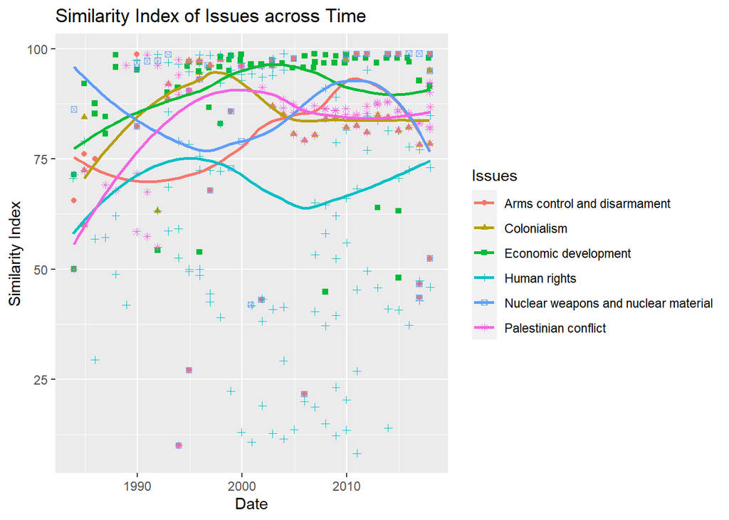

```r
ggplot(data = important,aes(x=date,y=similarity_index, group=issue)) +
    # facet_wrap(~issue) +
  geom_point(aes(shape=issue,color=issue),position="jitter") +
  geom_smooth(aes(color=issue),method=loess,se=FALSE) +
  labs(x="Date",y="Similarity Index",color="Issues",shape="Issues",title="Similarity Index of Issues across Time")
```

### Plot 2

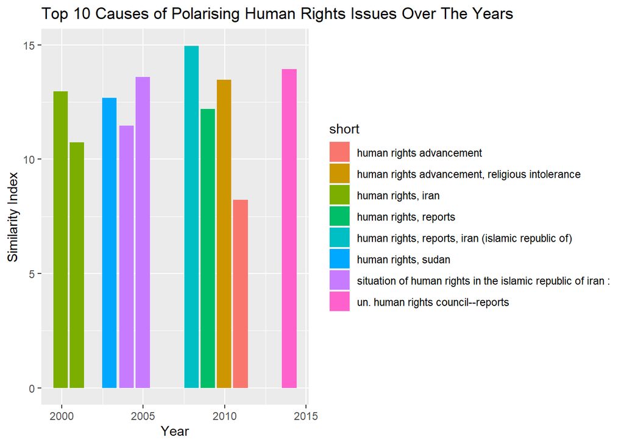

```r
# Filter out issues with more polarized data (similarity_index < 50) and find the issue with the highest frequency of polarized votes
short <- important %>%
  ungroup() %>%
  select(rcid,issue,date,similarity_index) %>%
  left_join(combined %>% select(rcid,short),by="rcid") %>%
  distinct() %>%
  na.omit() %>%
  filter(similarity_index < 50)

# Filter out the top 10 short descriptions with the lowest similarity index
hr <- short %>%
  filter(issue == "Human rights") %>%
  arrange(similarity_index) %>%
  top_n(-10, similarity_index) %>%
  mutate(short = tolower(short))

# Plot the bar graph of the top 10 human rights issues
ggplot(data = hr, aes(x = date, y = similarity_index, fill = short)) +
  geom_bar(stat = "identity", position = "dodge") +
  labs(x = "Year", y = "Similarity Index", title = "Top 10 Causes of Polarising Human Rights Issues Over The Years")
```

## Discussions

The first graph presented demonstrates that most issues are not highly polarised, with a similarity index of 75 or higher since 2000, except for human rights issues as seen from the consistently low similarity indexes associated with its regression line. Furthermore, the scatter plot shows that there is an observable surge of data points that fall below the regression line, and even below the 50 mark after around 2000. Most of these surges after 2000 are associated with human rights issues. When we filtered the top 10 human rights issues and plotted them on a bar graph, the results revealed the top issues occurred from 2000 to 2014, supporting our initial observations from the first graph.

According to the bar graph, the issue of human rights advancement in 2011 was found to be the most polarised with lowest similarity index. In 2011, UN’s Human Rights Chief, Navi Pillay, highlighted several global challenges to human rights, including economic, climate, energy, and food crises, armed conflicts, racism, and poverty. On the positive side, civil society was mobilised to challenge oppressive governance structures in the Middle East and North Africa. However, in some regions, legitimate demands for freedom and justice were met with violence and repression.

## References

1. https://www.ohchr.org/en/stories/2012/03/2011-was-year-critical-human-rights